# W_UP_01

Abel jacobo perez

24 aug 2021

The report structure should include five sections. see below

# Introduction

Create an Rstudio project in your shared space on rstudio.cloud. Using the dataset called pushups from the tigerstats package in R; answer the question posed by this null and alternate hypothesis in an html markdown document.

$H_0$: There is no difference between the average number of pushups of line vs skill players

$H_A$: The average number of pushups done by line players is statistically different than that of skill players.

# Methods

Because numerical is explained by categorical means that the t test was used

# Results

## Descriptive Results

### Graphical Descriptive Results

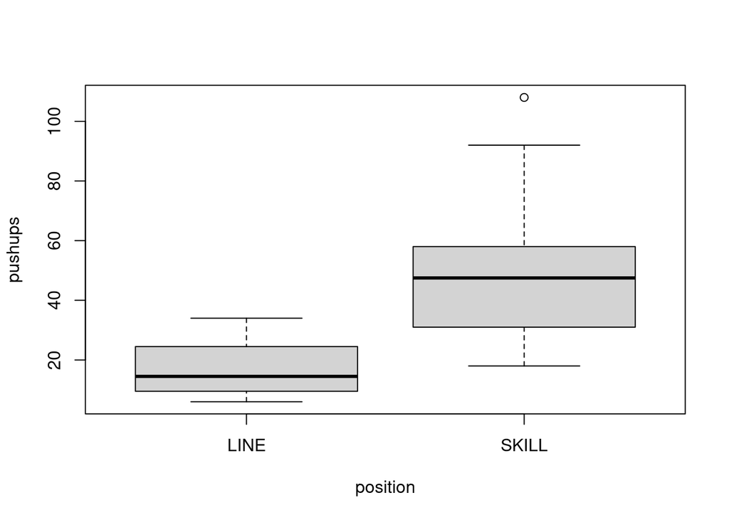

```r
boxplot(pushups~position,data=mydata)
```

this plot shows that th skilled players tend to do more pushups than do line players. The bottom of the skill box is higher/above almost all the line box.

### Numerical Descriptive Results

```r
favstats(pushups ~position,data=mydata)
```

```
##   position min    Q1 median    Q3 max     mean        sd  n missing
## 1     LINE   6 10.25   14.5 24.25  34 17.12500  9.745878  8       0
## 2    SKILL  18 31.25   47.5 57.50 108 49.72727 23.036579 22       0
```

## Inferential Results

```r
t.test(pushups~position,data=mydata)
```

```
##
##  Welch Two Sample t-test
##
## data:  pushups by position
## t = -5.4341, df = 27.079, p-value = 9.421e-06
## alternative hypothesis: true difference in means between group LINE and group SKILL is not equal to 0
## 95 percent confidence interval:
##  -44.91068 -20.29387
## sample estimates:
##  mean in group LINE mean in group SKILL
##            17.12500            49.72727
```

# Discussion and Conclusion

There is a difference between the number of pushups that skilled players and line players can do on average.The skilled players on average, can do more push ups then the line players can do.